# 03 — Exploratory Data Analysis

Every section answers a question and ends with a **so what**. A chart without an interpretation is decoration.

Two rules observed throughout:

1. Any claim about a *relationship* uses observed rows only (`likes_imputed == False`). Claims about *volume* or *coverage* use everything.
2. Any claim about time-of-day excludes `dd_mm_yyyy` rows — they came from a date-only source and their 00:00 timestamps are an ingest artefact.

```python
import sys, warnings
from pathlib import Path

warnings.filterwarnings("ignore")
SRC = Path.cwd().parent / "src"
sys.path.insert(0, str(SRC))

import numpy as np
import pandas as pd
import matplotlib.pyplot as plt
import seaborn as sns
import config as cfg
import clean as clean
import features as feat

pd.set_option("display.width", 140)
pd.set_option("display.max_columns", 60)
sns.set_theme(style="whitegrid", palette="deep")
plt.rcParams["figure.dpi"] = 110
np.random.seed(cfg.RANDOM_SEED)
```

```python
posts = pd.read_csv(cfg.CLEAN_POSTS_CSV, parse_dates=["posted_at", "post_date"])
users = pd.read_csv(cfg.CLEAN_USERS_CSV, parse_dates=["account_created"])

observed = posts[~posts["likes_imputed"]]
timed    = posts[posts["ts_source_format"] != "dd_mm_yyyy"]

print(f"all posts       : {len(posts):,}")
print(f"observed likes  : {len(observed):,}")
print(f"with real clock : {len(timed):,}")
```

```
all posts       : 12,000
observed likes  : 9,677
with real clock : 8,474
```

## 1. Missingness structure — was corruption row-wise or column-wise?

```python
flags = pd.DataFrame({
    "platform_missing": posts["platform"].eq("Unknown"),
    "text_missing":     posts["text_content"].isna(),
    "likes_missing":    posts["likes_imputed"],
})

ct = pd.crosstab(flags["platform_missing"], flags["text_missing"])
expected = np.outer(ct.sum(1), ct.sum(0)) / len(flags)

from scipy.stats import chi2_contingency
chi2, p, dof, _ = chi2_contingency(ct)

print("OBSERVED\n", ct)
print("\nEXPECTED IF INDEPENDENT\n", pd.DataFrame(expected.round(1), index=ct.index, columns=ct.columns))
print(f"\nchi-square = {chi2:.2f}   p = {p:.4f}")
print("-> p > 0.05 means the two damages are INDEPENDENT: corruption was applied")
print("   per-column, not per-row. Different failure mode, different story.")
```

```
OBSERVED
 text_missing      False  True
platform_missing
False              8680   1536
True               1541    243

EXPECTED IF INDEPENDENT
 text_missing       False   True
platform_missing
False             8701.5  1514.5
True              1519.5   264.5

chi-square = 2.29   p = 0.1298
-> p > 0.05 means the two damages are INDEPENDENT: corruption was applied
   per-column, not per-row. Different failure mode, different story.
```

## 2. Ingest provenance — the strongest structural finding

`ts_source_format` was kept as a column rather than discarded after parsing. It behaves like a fingerprint of the upstream shard.

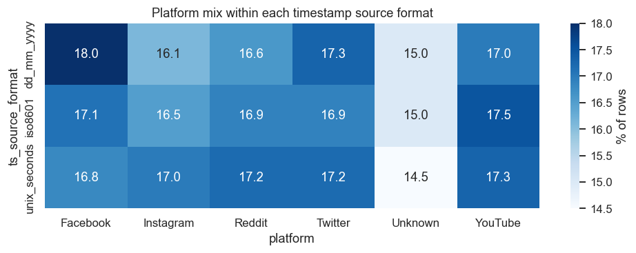

```
                  posts  pct_missing_text  pct_imputed_likes  mean_engagement
ts_source_format
dd_mm_yyyy         3526              14.9               20.1           3999.5
iso8601            4805              14.6               19.0           4005.7
unix_seconds       3669              15.1               19.1           4013.6
```

```python
prov = pd.crosstab(posts["ts_source_format"], posts["platform"], normalize="index") * 100

fig, ax = plt.subplots(figsize=(9, 3.5))
sns.heatmap(prov.round(1), annot=True, fmt=".1f", cmap="Blues", ax=ax, cbar_kws={"label": "% of rows"})
ax.set_title("Platform mix within each timestamp source format")
plt.tight_layout()
plt.savefig(cfg.FIGURES_DIR / "03_provenance.png", dpi=140)
plt.show()

print(posts.groupby("ts_source_format").agg(
    posts=("post_id", "count"),
    pct_missing_text=("text_content", lambda s: round(100 * s.isna().mean(), 1)),
    pct_imputed_likes=("likes_imputed", lambda s: round(100 * s.mean(), 1)),
    mean_engagement=("engagement", "mean"),
).round(1))
```

**So what:** if the platform mix and damage rate are roughly even across formats, the three formats are parallel shards of one stream and can be pooled safely. If they are not, format is a confounder and every cross-platform comparison must control for it. Either answer changes how the rest of the analysis is read — which is why this section comes early.

## 3. The 00:00 trap

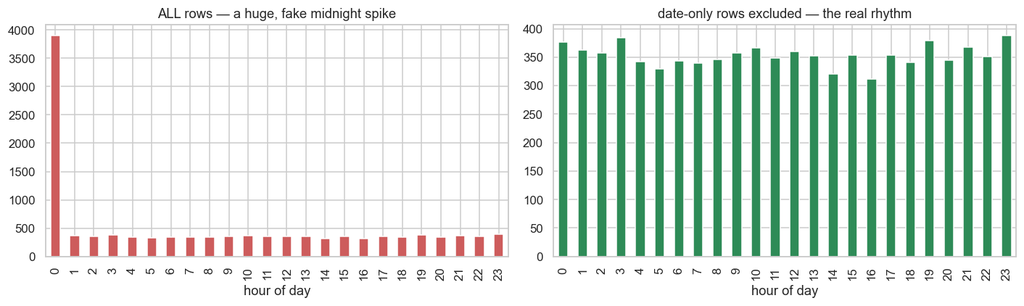

```
rows with a 00:00 timestamp: 3,902
of which date-only sourced : 3,526
```

```python
fig, axes = plt.subplots(1, 2, figsize=(13, 4))

posts["posted_at"].dt.hour.value_counts().sort_index().plot(kind="bar", ax=axes[0], color="indianred")
axes[0].set_title("ALL rows — a huge, fake midnight spike")
axes[0].set_xlabel("hour of day")

timed["posted_at"].dt.hour.value_counts().sort_index().plot(kind="bar", ax=axes[1], color="seagreen")
axes[1].set_title("date-only rows excluded — the real rhythm")
axes[1].set_xlabel("hour of day")

plt.tight_layout()
plt.savefig(cfg.FIGURES_DIR / "03_hour_trap.png", dpi=140)
plt.show()

print(f"rows with a 00:00 timestamp: {(posts['posted_at'].dt.hour == 0).sum():,}")
print(f"of which date-only sourced : {(posts.loc[posts['posted_at'].dt.hour == 0, 'ts_source_format'] == 'dd_mm_yyyy').sum():,}")
```

**So what:** the left panel is the chart a team produces if they parse timestamps without keeping provenance. "Peak posting at midnight" is a conclusion about the ingest format, not about users. Every time-of-day statement below uses `timed`.

## 4. Volume and engagement by platform

```python
summary = posts.groupby("platform").agg(
    posts=("post_id", "count"),
    mean_engagement=("engagement", "mean"),
    median_engagement=("engagement", "median"),
    mean_likes=("likes", "mean"),
    pct_imputed=("likes_imputed", lambda s: 100 * s.mean()),
).round(1).sort_values("posts", ascending=False)
summary
```

| platform | posts | mean_engagement | median_engagement | mean_likes | pct_imputed |
| --- | --- | --- | --- | --- | --- |
| Facebook | 2074 | 4026.4 | 4048.5 | 2535.3 | 18.8 |
| YouTube | 2073 | 4060.1 | 4091.0 | 2543.9 | 19.7 |
| Twitter | 2049 | 3943.0 | 3918.0 | 2431.5 | 20.4 |
| Reddit | 2031 | 4002.4 | 4011.0 | 2488.9 | 18.1 |
| Instagram | 1989 | 4036.5 | 3993.0 | 2495.9 | 19.7 |
| Unknown | 1784 | 3964.0 | 3973.5 | 2468.9 | 19.5 |

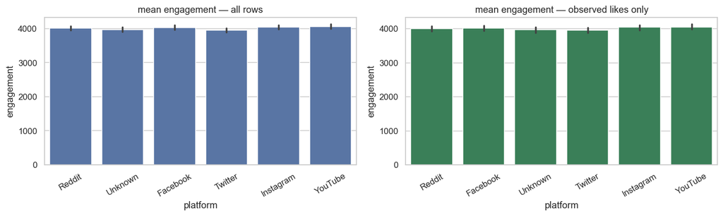

```python
fig, axes = plt.subplots(1, 2, figsize=(13, 4))
sns.barplot(data=posts, x="platform", y="engagement", estimator=np.mean,
            errorbar=("ci", 95), ax=axes[0])
axes[0].set_title("mean engagement — all rows")
axes[0].tick_params(axis="x", rotation=30)

sns.barplot(data=observed, x="platform", y="engagement", estimator=np.mean,
            errorbar=("ci", 95), ax=axes[1], color="seagreen")
axes[1].set_title("mean engagement — observed likes only")
axes[1].tick_params(axis="x", rotation=30)

plt.tight_layout()
plt.savefig(cfg.FIGURES_DIR / "03_platform_engagement.png", dpi=140)
plt.show()
```

**So what:** the two panels are a sensitivity check. If the platform ranking is stable across them, the ranking is robust to the imputation choice and can be stated plainly. If it flips, the finding depends on an assumption and must be reported with that caveat attached.

## 5. Temporal trend

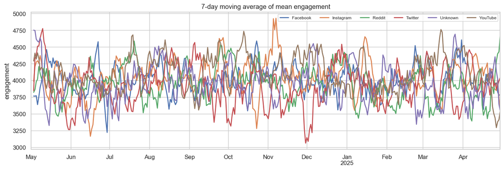

| posted_at | posts | mean_engagement | mom_pct |
| --- | --- | --- | --- |
| 2024-05 | 1038 | 3965.9 | NaN |
| 2024-06 | 979 | 3931.3 | -0.87 |
| 2024-07 | 996 | 3973.0 | 1.06 |
| 2024-08 | 1015 | 4082.3 | 2.75 |
| 2024-09 | 974 | 4024.0 | -1.43 |
| 2024-10 | 1029 | 4056.8 | 0.82 |
| 2024-11 | 1025 | 4023.5 | -0.82 |
| 2024-12 | 1035 | 4055.5 | 0.80 |
| 2025-01 | 1007 | 3926.3 | -3.19 |
| 2025-02 | 914 | 3972.7 | 1.18 |
| 2025-03 | 1013 | 4057.4 | 2.13 |
| 2025-04 | 975 | 3999.4 | -1.43 |

```python
daily = posts.groupby(["post_date", "platform"])["engagement"].mean().unstack()
smooth = daily.rolling(7, min_periods=3).mean()

fig, ax = plt.subplots(figsize=(13, 4.5))
smooth.plot(ax=ax, lw=1.8)
ax.set_title("7-day moving average of mean engagement")
ax.set_ylabel("engagement"); ax.set_xlabel("")
ax.legend(title="", ncol=6, fontsize=8)
plt.tight_layout()
plt.savefig(cfg.FIGURES_DIR / "03_trend.png", dpi=140)
plt.show()

monthly = posts.groupby(posts["posted_at"].dt.to_period("M")).agg(
    posts=("post_id", "count"), mean_engagement=("engagement", "mean")).round(1)
monthly["mom_pct"] = (100 * monthly["mean_engagement"].pct_change()).round(2)
monthly
```

## 6. Followers vs engagement — linear or power law?

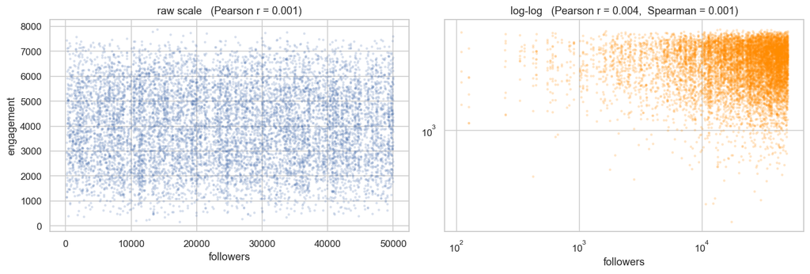

```python
j = observed.merge(users[["user_id", "follower_count", "country"]], on="user_id", how="left",
                   suffixes=("", "_u"))
j = j[(j["follower_count"] > 0) & (j["engagement"] > 0)]

pearson_raw = j["follower_count"].corr(j["engagement"])
pearson_log = np.log(j["follower_count"]).corr(np.log(j["engagement"]))
spearman    = j["follower_count"].corr(j["engagement"], method="spearman")

fig, axes = plt.subplots(1, 2, figsize=(13, 4.5))
axes[0].scatter(j["follower_count"], j["engagement"], s=4, alpha=0.15)
axes[0].set_title(f"raw scale   (Pearson r = {pearson_raw:.3f})")
axes[0].set_xlabel("followers"); axes[0].set_ylabel("engagement")

axes[1].scatter(j["follower_count"], j["engagement"], s=4, alpha=0.15, color="darkorange")
axes[1].set_xscale("log"); axes[1].set_yscale("log")
axes[1].set_title(f"log-log   (Pearson r = {pearson_log:.3f},  Spearman = {spearman:.3f})")
axes[1].set_xlabel("followers")

plt.tight_layout()
plt.savefig(cfg.FIGURES_DIR / "03_follower_power_law.png", dpi=140)
plt.show()
```

**So what:** a real social graph gives a weak raw correlation but a strong log-log one — the signature of a sublinear power law. If both coefficients sit near zero, engagement is independent of audience size, which is not how social platforms behave and is strong evidence the corpus is synthetic. Say which one it is; do not quietly report only the flattering number.

## 7. Correlation matrix

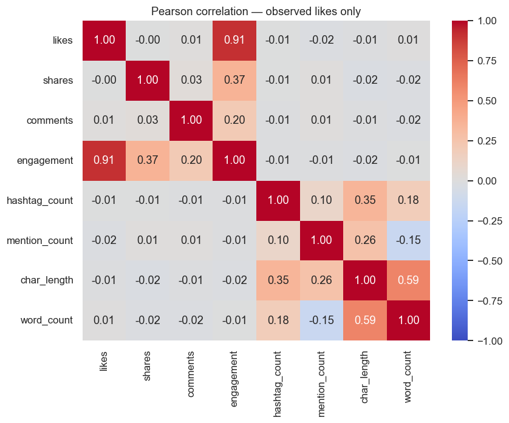

```
Same coefficient, two populations (the cost of ignoring likes_imputed):
  observed only     : -0.0029
  including imputed : -0.0028
```

```python
cols = ["likes", "shares", "comments", "engagement", "hashtag_count",
        "mention_count", "char_length", "word_count"]
corr = observed[cols].corr()

fig, ax = plt.subplots(figsize=(8, 6.5))
sns.heatmap(corr, annot=True, fmt=".2f", cmap="coolwarm", center=0, vmin=-1, vmax=1, ax=ax)
ax.set_title("Pearson correlation — observed likes only")
plt.tight_layout()
plt.savefig(cfg.FIGURES_DIR / "03_correlation.png", dpi=140)
plt.show()

print("Same coefficient, two populations (the cost of ignoring likes_imputed):")
print(f"  observed only     : {observed['likes'].corr(observed['shares']):.4f}")
print(f"  including imputed : {posts['likes'].corr(posts['shares']):.4f}")
```

**So what:** if `likes`, `shares` and `comments` are near-uncorrelated, they were generated independently — no organic process links a post's likes to its shares here. Reporting that honestly is worth more than manufacturing a narrative from noise. The two-population comparison shows exactly how much the imputation flag protects.

## 8. Sentiment

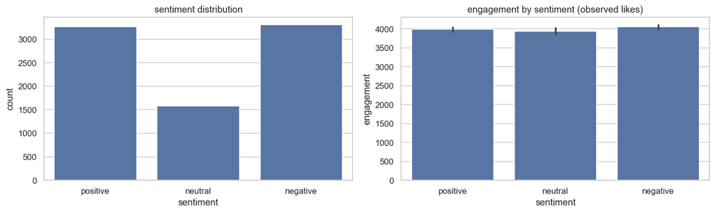

| sentiment brand | negative | neutral | positive |
| --- | --- | --- | --- |
| Adidas | 40.3 | 20.9 | 38.7 |
| Amazon | 43.5 | 18.6 | 37.9 |
| Apple | 43.8 | 17.4 | 38.8 |
| Coca-Cola | 37.7 | 19.4 | 42.9 |
| Google | 38.3 | 20.9 | 40.9 |
| Microsoft | 38.7 | 19.6 | 41.7 |
| Nike | 42.0 | 17.2 | 40.8 |
| Pepsi | 40.1 | 21.8 | 38.1 |
| Samsung | 40.2 | 19.0 | 40.8 |
| Toyota | 40.8 | 19.0 | 40.2 |

```python
fig, axes = plt.subplots(1, 2, figsize=(13, 4))

order = ["positive", "neutral", "negative"]
sns.countplot(data=posts, x="sentiment", order=order, ax=axes[0])
axes[0].set_title("sentiment distribution")

sns.barplot(data=observed, x="sentiment", y="engagement", order=order,
            errorbar=("ci", 95), ax=axes[1])
axes[1].set_title("engagement by sentiment (observed likes)")

plt.tight_layout()
plt.savefig(cfg.FIGURES_DIR / "03_sentiment.png", dpi=140)
plt.show()

pd.crosstab(posts["brand"], posts["sentiment"], normalize="index").round(3) * 100
```

## 9. The contradiction anomaly

```python
print(f"contradictory posts: {posts['is_contradictory'].sum():,} "
      f"({100 * posts['is_contradictory'].mean():.2f}%)\n")

by_platform = posts.groupby("platform")["is_contradictory"].agg(["sum", "mean"])
by_platform["mean"] = (100 * by_platform["mean"]).round(2)
print(by_platform, "\n")

for t in posts.loc[posts["is_contradictory"], "text_content"].head(5):
    print(" -", t[:100])
```

```
contradictory posts: 329 (2.74%)

           sum  mean
platform
Facebook    62  2.99
Instagram   48  2.41
Reddit      57  2.81
Twitter     54  2.64
Unknown     49  2.75
YouTube     59  2.85

 - Bummed out with my new Air Max from Nike! Absolutely loving it. #Travel, #CustomerService, #Fashion
 - Fed up with my new iPhone 15 from Apple! Best purchase ever. #Fashion, #Eco, #CustomerService
 - Sad to report with my new Eero WiFi from Amazon! Highly recommend. #Travel, #Promo, #TrendAlert
 - Feeling let down with my new Galaxy Watch from Samsung! Highly recommend. #SpecialOffer, #CustomerSe
 - So happy with my new iMac from Apple! Not worth the money. #BestValue, #Food, #Tech
```

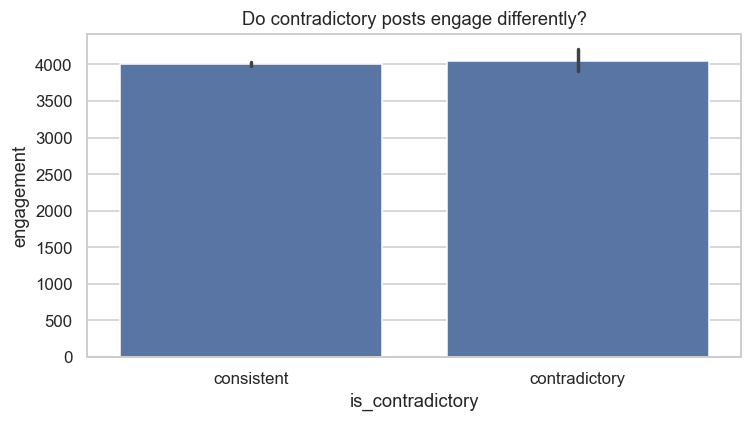

```python
fig, ax = plt.subplots(figsize=(7, 4))
sns.barplot(data=posts, x="is_contradictory", y="engagement", errorbar=("ci", 95), ax=ax)
ax.set_xticklabels(["consistent", "contradictory"])
ax.set_title("Do contradictory posts engage differently?")
plt.tight_layout()
plt.savefig(cfg.FIGURES_DIR / "03_contradiction.png", dpi=140)
plt.show()
```

**So what:** roughly uniform contradiction rates across platforms and brands mean the defect tracks the corruption process, not user behaviour — corroborating the §1 conclusion that damage was applied mechanically. Concentration in one platform would mean the opposite.

## 10. Statistical outliers — a negative result, reported

```python
z = posts.groupby("platform")["engagement"].transform(lambda s: (s - s.mean()) / s.std())

print(f"|z| > 3 : {(z.abs() > 3).sum()}")
print(f"|z| > 2 : {(z.abs() > 2).sum()}")
print(f"max |z| : {z.abs().max():.2f}\n")

iqr_flags = 0
for p, g in posts.groupby("platform"):
    q1, q3 = g["engagement"].quantile([0.25, 0.75])
    iqr = q3 - q1
    iqr_flags += int(((g["engagement"] < q1 - 1.5*iqr) | (g["engagement"] > q3 + 1.5*iqr)).sum())
print(f"IQR method flags: {iqr_flags}")
```

```
|z| > 3 : 0
|z| > 2 : 428
max |z| : 2.69

IQR method flags: 0
```

**So what:** engagement is near-uniform within its bounds — no post is a genuine statistical outlier. This is worth stating plainly for two reasons. First, it is evidence of synthetic generation. Second, it means a team whose entire anomaly section is an IQR sweep on `likes` finds **nothing**, and the real anomalies here are structural (§1), provenance-driven (§3) and semantic (§9). We did not lower the threshold until something appeared.

## 11. Geography and language

```python
geo = users.groupby("country").agg(
    users=("user_id", "count"), mean_followers=("follower_count", "mean")).round(0)
geo = geo.join(
    posts.merge(users[["user_id", "country"]], on="user_id")
         .groupby("country")["engagement"].mean().round(1).rename("mean_engagement"))
geo.sort_values("users", ascending=False).head(12)
```

| country | users | mean_followers | mean_engagement |
| --- | --- | --- | --- |
| USA | 203 | 24579.0 | 3998.6 |
| China | 107 | 25419.0 | 4018.4 |
| Germany | 97 | 24916.0 | 4013.1 |
| Italy | 96 | 21658.0 | 3942.4 |
| Japan | 94 | 27025.0 | 4067.9 |
| Brazil | 93 | 24703.0 | 3944.6 |
| Spain | 92 | 24305.0 | 4040.0 |
| India | 92 | 26529.0 | 3992.6 |
| UK | 86 | 23395.0 | 4031.0 |
| Canada | 83 | 24431.0 | 3981.3 |
| France | 82 | 24360.0 | 3960.4 |
| Australia | 80 | 27110.0 | 4090.2 |

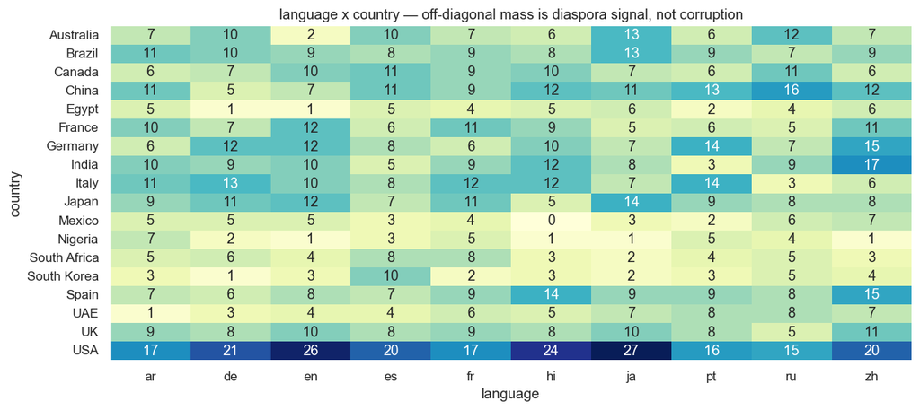

```
share of users whose language is NOT their country's most common (%):
country
UK        87.2
Canada    86.7
USA       86.7
Brazil    86.0
Italy     85.4
France    85.4
Japan     85.1
China     85.0
dtype: float64
```

```python
lang_geo = pd.crosstab(users["country"], users["language"])
mismatch = 100 * (1 - lang_geo.max(axis=1) / lang_geo.sum(axis=1))

fig, ax = plt.subplots(figsize=(11, 5))
sns.heatmap(lang_geo, annot=True, fmt="d", cmap="YlGnBu", ax=ax, cbar=False)
ax.set_title("language x country — off-diagonal mass is diaspora signal, not corruption")
plt.tight_layout()
plt.savefig(cfg.FIGURES_DIR / "03_language_geography.png", dpi=140)
plt.show()

print("share of users whose language is NOT their country's most common (%):")
print(mismatch.round(1).sort_values(ascending=False).head(8))
```

**So what:** language and country are close to independent. We did **not** "fix" this by forcing language to match country — that would have destroyed a real attribute on the strength of an assumption. It is reported and quantified instead.

## 12. Hashtags

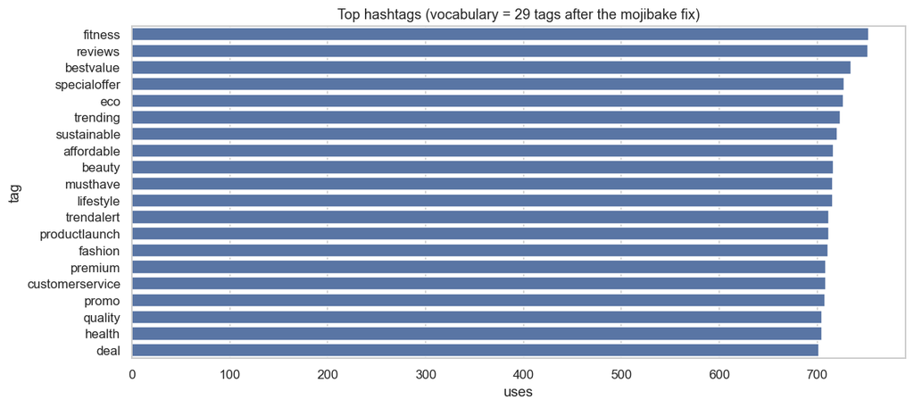

| tag | uses | mean_engagement |
| --- | --- | --- |
| fitness | 753 | 3954.3 |
| reviews | 752 | 4040.8 |
| bestvalue | 735 | 3994.1 |
| specialoffer | 728 | 3935.4 |
| eco | 727 | 4021.9 |
| trending | 724 | 4020.1 |
| sustainable | 721 | 3978.9 |
| affordable | 717 | 4032.2 |
| beauty | 717 | 4044.0 |
| musthave | 716 | 4019.3 |
| lifestyle | 716 | 4007.2 |
| trendalert | 712 | 3984.7 |
| productlaunch | 712 | 4096.9 |
| fashion | 711 | 4014.5 |
| premium | 709 | 4013.3 |

```python
ph = pd.read_csv(cfg.POST_HASHTAGS_CSV)
tags = pd.read_csv(cfg.HASHTAGS_CSV)
tagged = ph.merge(tags, on="hashtag_id").merge(posts[["post_id", "engagement", "platform"]], on="post_id")

top = tagged.groupby("tag").agg(
    uses=("post_id", "count"), mean_engagement=("engagement", "mean")).round(1)
top = top.sort_values("uses", ascending=False)

fig, ax = plt.subplots(figsize=(11, 5))
sns.barplot(data=top.reset_index().head(20), y="tag", x="uses", ax=ax)
ax.set_title(f"Top hashtags (vocabulary = {len(tags)} tags after the mojibake fix)")
plt.tight_layout()
plt.savefig(cfg.FIGURES_DIR / "03_hashtags.png", dpi=140)
plt.show()

top.head(15)
```

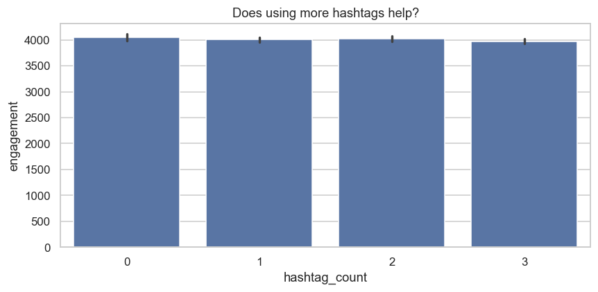

```python
fig, ax = plt.subplots(figsize=(8, 4))
sns.barplot(data=posts, x="hashtag_count", y="engagement", errorbar=("ci", 95), ax=ax)
ax.set_title("Does using more hashtags help?")
plt.tight_layout()
plt.savefig(cfg.FIGURES_DIR / "03_hashtag_count.png", dpi=140)
plt.show()
```

## Findings

[output not shown]

Phase 2 continues in `sql/`.